# Lab 3: Linear Regression Model Comparisons

Author

Dan Czink

```r
#install.packages("tidyr")
#install.packages("ggplot2")
#install.packages("broom")
#install.packages("performance")
#install.packages("gt")
#install.packages("dplyr")
```

```r
library(tidyr)
library(ggplot2)
library(broom)
library(performance)
library(gt)
library(dplyr)
```

## Load and clean the dataset

```r
data <- attitude

data.clean <- attitude |>
  select(rating, complaints, learning, raises) |>
  drop_na()

n <- nrow(data.clean)
```

The data set attitude is a build-in R data set that includes overall workplace ratings from 30 departments. Handling of employee complaints, opportunity to learn, and pay raises will be used as predictor variables.

The final analysis included all **30 departments**.

It is expected that the handling of workplace complaints be positively associated with overall workplace ratings because it shows that any problems seen in the workplace are being addressed. Opportunities for learning are expected to be positively associated with overall workplace rating beyond handling of complaints as more opportunities can give employees a sense of growth and accomplishment and make them more satisfied with their job. Pay increase is expected to be positively associated with workplace rating above and beyond the other two variables because even if complaints are dealt with and learning is fostered, it is unlikely that employees would rate a workplace positively if they are not being fairly compensated for their improvement and inflation.

## Explore the data

### Descriptive Statistics

```r
descriptives <- data.clean |>
  summarize(across(c(rating, complaints, learning, raises),
            list(mean = mean,
                 sd = sd,
                 min = min,
                 max = max)
            )) |>
  pivot_longer(everything(),
               names_to = c("variable", ".value"),
               names_sep = "_")

descriptives |>
  gt() |>
  fmt_number(columns = where(is.numeric), decimals = 2)
```

Descriptive Statistics for All Variables

| variable | mean | sd | min | max |
| --- | --- | --- | --- | --- |
| rating | 64.63 | 12.17 | 40.00 | 85.00 |
| complaints | 66.60 | 13.31 | 37.00 | 90.00 |
| learning | 56.37 | 11.74 | 34.00 | 75.00 |
| raises | 64.63 | 10.40 | 43.00 | 88.00 |

### Distribution of rating

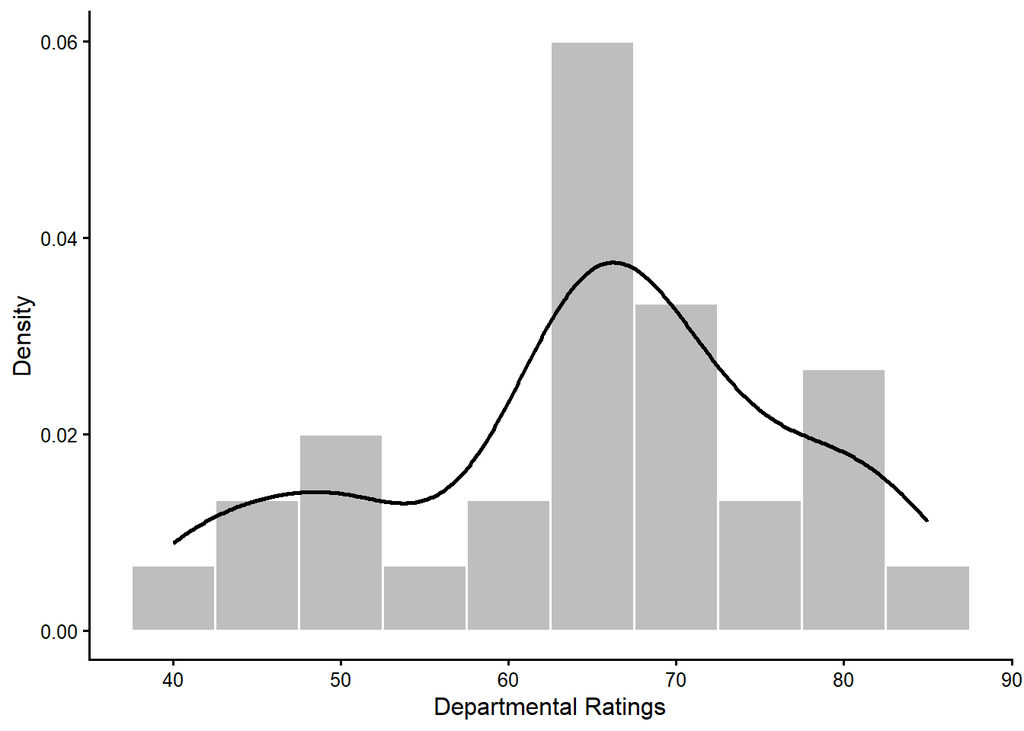

```r
ggplot(data.clean, aes(x = rating)) +
  geom_histogram(
    aes(y = after_stat(density)),
    bins = 10,
    fill = "gray",
    colour = "white") +
  geom_density(
    linewidth = 1.0,
    colour = "black")+
  labs(
    x = "Departmental Ratings",
    y = "Density") +
  theme_classic(base_size = 12)
```

### Relationship Between Predictors and Overall Rating

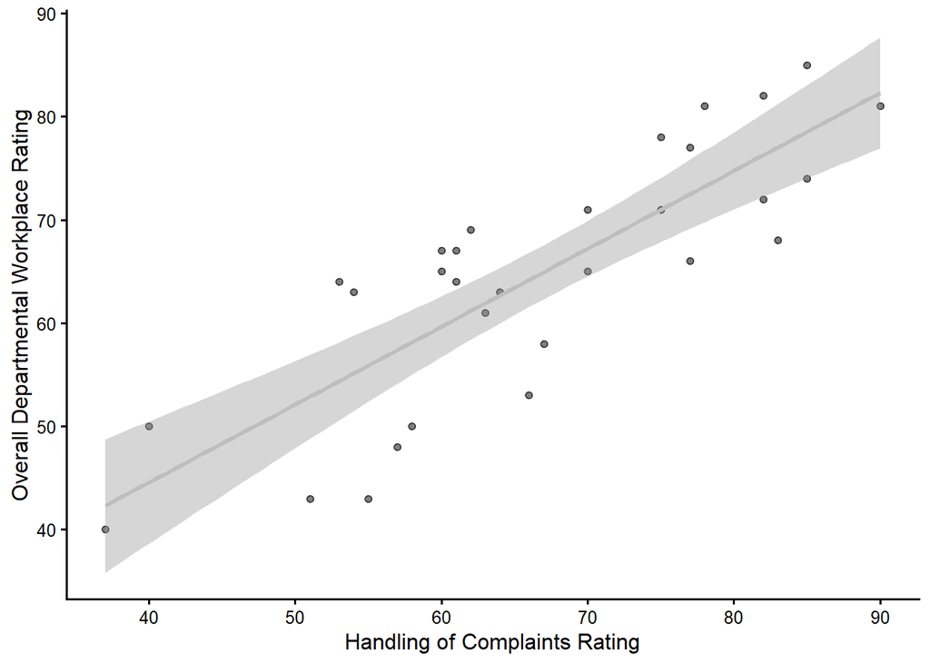

Relationship between Handling of Complaints and Overall Rating

```r
ggplot(data.clean, aes(x = complaints, y = rating)) +
  geom_point(alpha = 0.5) +
  geom_smooth(
    method = "lm",
    se = TRUE,
    color = "gray"
  ) +
  labs(
    x = "Handling of Complaints Rating",
    y = "Overall Departmental Workplace Rating"
  ) +
  theme_classic(base_size = 12)
```

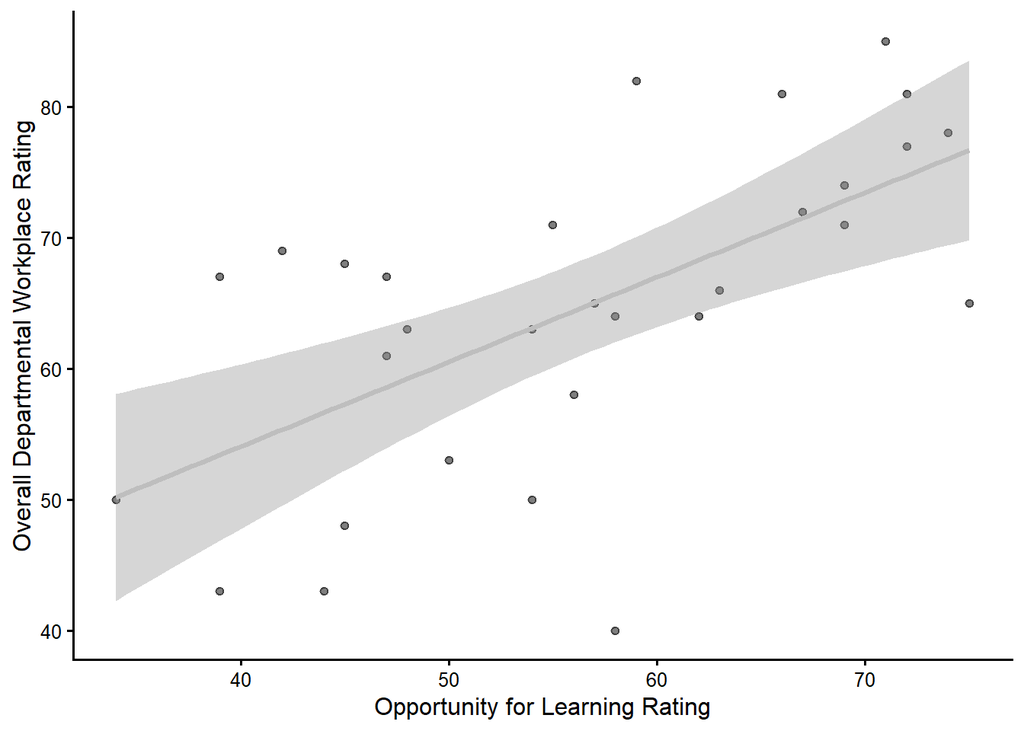

Relationship between Opportunity for Learning and Overall Rating

```r
ggplot(data.clean, aes(x = learning, y = rating)) +
  geom_point(alpha = 0.5) +
  geom_smooth(
    method = "lm",
    se = TRUE,
    color = "gray"
  ) +
  labs(
    x = "Opportunity for Learning Rating",
    y = "Overall Departmental Workplace Rating"
  ) +
  theme_classic(base_size = 12)
```

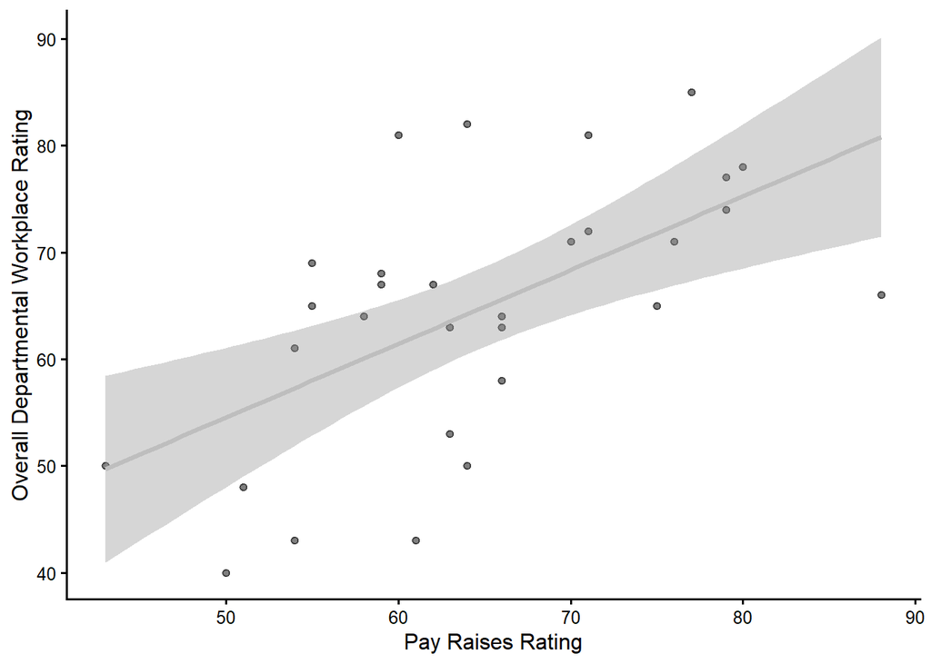

Relationship between Pay Raises and Overall Rating

```r
ggplot(data.clean, aes(x = raises, y = rating)) +
  geom_point(alpha = 0.5) +
  geom_smooth(
    method = "lm",
    se = TRUE,
    color = "gray"
  ) +
  labs(
    x = "Pay Raises Rating",
    y = "Overall Departmental Workplace Rating"
  ) +
  theme_classic(base_size = 12)
```

From the above plots, we can see that the distribution of overall ratings is approximately normal and the relationships between predictor variables and outcome appear linear. There is one pay raise observation that appears to be extremely high though based on the regression line it does not appear to be overly influential.

## Create and Evaluate Competing Models

**Nested** models will be created starting at the intercept and increasing in complexity as more variables are added to the previous model.

| Model | Formula | Research rationale |
| --- | --- | --- |
| M0: Null | `rating ~ 1` | Baseline model |
| M1: Complaints | `rating ~ complaints` | Evaluate complaint handling |
| M2: Complaints + Learning | `rating ~ complaints + learning` | Evaluate the additional contribution of learning |
| M3: Expanded | `rating ~ complaints + learning + raises` | Evaluate the additional contribution of pay raises |

### Fit the Nested Models

```r
# Intercept-only model
model_1 <- lm(rating ~ 1, data = data.clean)

# complaints model
model_2 <- lm(rating ~ complaints, data = data.clean)

# complaints + learning model
model_3 <- lm(rating ~ complaints + learning, data = data.clean)

# Expanded model
model_4 <- lm(rating ~ complaints + learning + raises, data = data.clean)
```

### Inspect the Nested Models

```r
summary(model_1)
```

```
Call:
lm(formula = rating ~ 1, data = data.clean)

Residuals:
     Min       1Q   Median       3Q      Max
-24.6333  -5.8833   0.8667   7.1167  20.3667

Coefficients:
            Estimate Std. Error t value Pr(>|t|)
(Intercept)   64.633      2.222   29.08   <2e-16 ***
---
Signif. codes:  0 '***' 0.001 '**' 0.01 '*' 0.05 '.' 0.1 ' ' 1

Residual standard error: 12.17 on 29 degrees of freedom
```

```r
summary(model_2)
```

```
Call:
lm(formula = rating ~ complaints, data = data.clean)

Residuals:
     Min       1Q   Median       3Q      Max
-12.8799  -5.9905   0.1783   6.2978   9.6294

Coefficients:
            Estimate Std. Error t value Pr(>|t|)
(Intercept) 14.37632    6.61999   2.172   0.0385 *
complaints   0.75461    0.09753   7.737 1.99e-08 ***
---
Signif. codes:  0 '***' 0.001 '**' 0.01 '*' 0.05 '.' 0.1 ' ' 1

Residual standard error: 6.993 on 28 degrees of freedom
Multiple R-squared:  0.6813,    Adjusted R-squared:  0.6699
F-statistic: 59.86 on 1 and 28 DF,  p-value: 1.988e-08
```

```r
summary(model_3)
```

```
Call:
lm(formula = rating ~ complaints + learning, data = data.clean)

Residuals:
     Min       1Q   Median       3Q      Max
-11.5568  -5.7331   0.6701   6.5341  10.3610

Coefficients:
            Estimate Std. Error t value Pr(>|t|)
(Intercept)   9.8709     7.0612   1.398    0.174
complaints    0.6435     0.1185   5.432 9.57e-06 ***
learning      0.2112     0.1344   1.571    0.128
---
Signif. codes:  0 '***' 0.001 '**' 0.01 '*' 0.05 '.' 0.1 ' ' 1

Residual standard error: 6.817 on 27 degrees of freedom
Multiple R-squared:  0.708, Adjusted R-squared:  0.6864
F-statistic: 32.74 on 2 and 27 DF,  p-value: 6.058e-08
```

```r
summary(model_4)
```

```
Call:
lm(formula = rating ~ complaints + learning + raises, data = data.clean)

Residuals:
     Min       1Q   Median       3Q      Max
-11.6282  -5.8107   0.5115   6.3946  10.3509

Coefficients:
            Estimate Std. Error t value Pr(>|t|)
(Intercept) 10.52260    8.30481   1.267    0.216
complaints   0.65349    0.13637   4.792 5.82e-05 ***
learning     0.22069    0.14967   1.475    0.152
raises      -0.02864    0.18245  -0.157    0.876
---
Signif. codes:  0 '***' 0.001 '**' 0.01 '*' 0.05 '.' 0.1 ' ' 1

Residual standard error: 6.943 on 26 degrees of freedom
Multiple R-squared:  0.7083,    Adjusted R-squared:  0.6746
F-statistic: 21.04 on 3 and 26 DF,  p-value: 3.957e-07
```

```r
confint(model_4)
```

```
                  2.5 %     97.5 %
(Intercept) -6.54817583 27.5933815
complaints   0.37316545  0.9338110
learning    -0.08695739  0.5283289
raises      -0.40366218  0.3463882
```

In Model 1, the intercept represents the sample mean occupational rating. In Model 2, the complaints coefficient represents the expected increase in rating associated with one additional rating of average complaint handling. In Model 3, the complaints coefficient represents this increase after adjusting for the rating of opportunity for learning. While the increase lowers, complaints remains a significant predictor of overall rating. Learning has a non-significant association with rating when complaints are held constant, but the addition of learning slightly increases the variance explained by the model. In Model 4, complaints and learning coefficients are additionally adjusted for pay raises. Learning and pay rises both have a non-significant association with overall rating when complaints are held constant. The inclusion of pay raises with learning increases the complaints coefficient above solely the inclusion of learning.

## Compare the models

Model performance will be evaluated using nested-model F-tests and overall model performance

### Nested-Model Comparisons

```r
nested.tests <- anova(model_1, model_2, model_3, model_4)

nested.tests
```

```
Analysis of Variance Table

Model 1: rating ~ 1
Model 2: rating ~ complaints
Model 3: rating ~ complaints + learning
Model 4: rating ~ complaints + learning + raises
  Res.Df    RSS Df Sum of Sq       F    Pr(>F)
1     29 4297.0
2     28 1369.4  1   2927.58 60.7256 2.884e-08 ***
3     27 1254.6  1    114.73  2.3799    0.1350
4     26 1253.5  1      1.19  0.0246    0.8765
---
Signif. codes:  0 '***' 0.001 '**' 0.01 '*' 0.05 '.' 0.1 ' ' 1
```

```r
nested.tests <- nested.tests |>
  select(Res.Df, Df, F, `Pr(>F)`) |>
  rename(
    Residual.Df = Res.Df,
    Nested.Df = Df,
    Nested.F.stat = F,
    Nested.p.value = `Pr(>F)`
  )
```

### Overall Model Performance

```r
glance1 <- glance(model_1)
glance2 <- glance(model_2)
glance3 <- glance(model_3)
glance4 <- glance(model_4)

performance <- rbind(glance1, glance2, glance3, glance4)
```

### Combine Performance Tests, Calculate RMSE and Delta R Squared

```r
models <- c(
  "M1: Null",
  "M2: Complaints",
  "M3: Complaints + Learning",
  "M4: Complaints + Learning + Raises"
)

comparison.table <- cbind(
  Model = models,
  performance,
  nested.tests
)

comparison.table <- comparison.table |>
  mutate(Delta.R2 = r.squared - lag(r.squared),
         RMSE = c(
           sqrt(mean(residuals(model_1)^2)),
           sqrt(mean(residuals(model_2)^2)),
           sqrt(mean(residuals(model_3)^2)),
           sqrt(mean(residuals(model_4)^2)))
  ) |>
  select(
    Model,
    r.squared,
    adj.r.squared,
    RMSE,
    Delta.R2,
    Residual.Df,
    Nested.Df,
    Nested.F.stat,
    Nested.p.value
  )
```

### Display the combined model-comparison table

```r
comparison.table |>
  gt() |>
  cols_label(
    Model = "Model",
    r.squared = "R²",
    adj.r.squared = "Adjusted R²",
    RMSE = "RMSE",
    Delta.R2 = "ΔR²",
    Residual.Df = "Residual Df",
    Nested.Df = "Nested df",
    Nested.F.stat = "Nested F",
    Nested.p.value = "Nested p"
  ) |>
  fmt_number(
    columns = c(
      r.squared,
      Delta.R2,
      adj.r.squared,
      RMSE,
      Nested.F.stat
    ),
    decimals = 2
  ) |>
  fmt_number(
    columns = Nested.p.value,
    decimals = 3
    ) |>
  sub_missing(
    columns = c(Delta.R2, Nested.Df, Nested.F.stat),
    missing_text = "—"
  ) |>
  tab_spanner(
    label="Overall Performance",
    columns = c(r.squared, adj.r.squared, RMSE)
  )|>
  tab_spanner(
    label="Incremental Improvements",
    columns = c(Delta.R2, Residual.Df, Nested.Df, Nested.F.stat, Nested.p.value)
  )
```

Overall Model Performance and Incremental Nested Model Improvements

| Model | Overall Performance R² | Overall Performance Adjusted R² | Overall Performance RMSE | Incremental Improvements ΔR² | Incremental Improvements Residual Df | Incremental Improvements Nested df | Incremental Improvements Nested F | Incremental Improvements Nested p |
| --- | --- | --- | --- | --- | --- | --- | --- | --- |
| M1: Null | 0.00 | 0.00 | 11.97 | — | 29 | — | — | NA |
| M2: Complaints | 0.68 | 0.67 | 6.76 | 0.68 | 28 | 1 | 60.73 | 0.000 |
| M3: Complaints + Learning | 0.71 | 0.69 | 6.47 | 0.03 | 27 | 1 | 2.38 | 0.135 |
| M4: Complaints + Learning + Raises | 0.71 | 0.67 | 6.46 | 0.00 | 26 | 1 | 0.02 | 0.876 |

### Interpreting the combined table

Models 3 and 4 explain a greater proportion of variance in overall rating than model 2, but equal to each other. This suggests that the addition of opportunity for learning explains more variance than complaints alone, though that pay raises does not contribute additional information to complaints and learning. This is confirmed by the adjusted R2, which is at its highest in Model 3 but then lowers to the level of Model 2 in Model 4 when pay raise is added. That said, only adding complaints in Model 2 compared to the Null Model 1 produces a statistically significant improvement in fit. Root mean squared error decreases substantially between models 1 and 2. While Root mean squared error does decrease between models 2 and 3, and again between Models 3 and 4, the latter decrease does not appear meaningful.

### Select the Best Model

```r
selected.row <- comparison.table |>
  slice_max(
    order_by = adj.r.squared,
    n = 1,
    with_ties = FALSE
  )

selected.name <- selected.row$Model

selected.model <- switch(
  selected.name,
  "M1: Null" = model_1,
  "M2: Complaints" = model_2,
  "M3: Complaints + Learning" = model_3,
  "M4: Complaints + Learning + Raises" = model_4
)
```

The model selected by the greatest Adjusted R2 is **M3: Complaints + Learning**.

Its performance is R² = **0.71**, Adjusted R² = **0.69**, and RMSE = **6.47** ratings.

## Check Model Assumptions

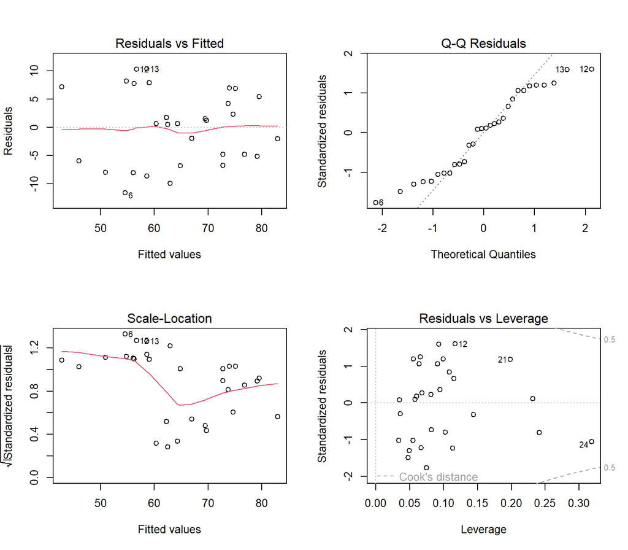

Regression diagnostic plots for Model 3

```r
op <- par(mfrow = c(2, 2))

plot(selected.model)
```

```r
par(op)

check_collinearity(selected.model)
```

```
# Check for Multicollinearity

Low Correlation

       Term  VIF   VIF 95% CI adj. VIF Tolerance Tolerance 95% CI
 complaints 1.55 [1.10, 2.25]     1.25      0.64     [0.44, 0.91]
   learning 1.55 [1.10, 2.25]     1.25      0.64     [0.44, 0.91]
```

### Evaluation of Assumptions

In all, while heteroscedasticity is questionable, there were no blatantly violated assumptions that would be cause for concern in interpreting Model 3.

## Report the selected model

Model 3 is the chosen most appropriate model as it has the highest adjusted R2 of all the models while limiting the root mean square error. While it is not the lowest root mean square error, Model 4 is only 1 hundredth lower, which is not a meaningful difference. This is the 2nd most complex model, though the most complex (Model 4) does not offer an increase in variation explained nor does it reduce the root mean squared error in a meaningful way. Moreover, Model 3 does not substantially violate any assumptions, allowing it to remain interpretable.

### Compute Model 3’s coefficients

```r
model.results <- tidy(
  selected.model,
  conf.int = TRUE,
  conf.level = 0.95
)
```

### Create a Coefficient Table

```r
model.results |>
  select(
    term,
    estimate,
    std.error,
    conf.low,
    conf.high,
    p.value
  ) |>
  gt() |>
  cols_label(
    term = "Predictor Name",
    estimate = "Unstandardized Estimate",
    std.error = "Standard Error",
    conf.low = "95% CI Lower",
    conf.high = "95% CI Upper",
    p.value = "p-value"
  ) |>
  fmt_number(
    columns = c(
      estimate,
      std.error,
      conf.low,
      conf.high
    ),
    decimals = 2
  ) |>
  fmt_number(
    columns = p.value, decimals = 3
    ) |>
  fmt(
    columns = p.value,
    fns = function(x) {
      ifelse(
        x < .001,
        "< .001",
        sprintf("%.3f", x)
      )
    }
  )
```

Unstandardized Regression Coefficients for Model 3

| Predictor Name | Unstandardized Estimate | Standard Error | 95% CI Lower | 95% CI Upper | p-value |
| --- | --- | --- | --- | --- | --- |
| (Intercept) | 9.87 | 7.06 | −4.62 | 24.36 | 0.174 |
| complaints | 0.64 | 0.12 | 0.40 | 0.89 | < .001 |
| learning | 0.21 | 0.13 | −0.06 | 0.49 | 0.128 |

## 8. Interpret the results

The selected model, **M3: Complaints + Learning**, explains approximately **70.8%** of the variation in overall departmental ratings. Holding opportunities for learning constant, a one-point increase in a departments’ handling of complaints is associated with a significant **0.64-point** increase in predicted overall workplace rating, 95% CI [0.4, 0.89]. Holding handling of complaints constant, a one-point increase in a departments’ opportunities for learning is associated with a non-significant **0.21-point** increase in predicted overall workplace rating, 95% CI [-0.06, 0.49].

### Overall Model Performance

```r
selected.row |>
  select(
    Model,
    r.squared,
    adj.r.squared,
    RMSE
  ) |>
  gt() |>
  cols_label(
    Model = "Model",
    r.squared = "R²",
    adj.r.squared = "Adjusted R²",
    RMSE = "RMSE"
  ) |>
  fmt_number(
    columns = where(is.numeric),
    decimals = 2
  )
```

Overall performance of Model 3

| Model | R² | Adjusted R² | RMSE |
| --- | --- | --- | --- |
| M3: Complaints + Learning | 0.71 | 0.69 | 6.47 |

### Overall model performance

Model 3’s adjusted R² is **0.69**, and its in-sample RMSE is **6.47 overall rating points**.

### Substantive conclusions

This analysis illustrates how departmental workplace ratings can be investigated using several nested linear regression models. We were able to determine that handling of complaints remained a significant predictor of overall workplace rating even when opportunities for learning and pay raise were held constant. We were also able to determine that opportunities for learning and pay raise were non-significant while handling of complaints were held constant, suggesting that this is the most important factor in determining workplace ratings in this sample. Finally, opportunities for learning, but not pay raise, were able to explain additional variation above what could be explained by handling of complaints alone.

However, these finding should be considered with the following limitation in mind. The observations included in this sample are averaged among departments and not individual employees, possible obscuring important variability within those departments.